# expo_dataset_visualization

the data we choose is 2008 expo data set which consists of data for flight arrival and departure details for all commercial flights within the USA in 2008

```python
# importing important libraries
import pandas as pd
import numpy as np
import matplotlib.pyplot as plt
import seaborn as sb
%matplotlib inline
```

```python
# setting options of pandas to see all columns and rows
pd.set_option('display.max_rows',None)
pd.set_option('display.max_columns',None)
```

```python
# loading the data set
df = pd.read_csv('2008.csv')
```

```python
df.head() # showing first five rows to know our data set better
```

|  | Year | Month | DayofMonth | DayOfWeek | DepTime | CRSDepTime | ArrTime | CRSArrTime | UniqueCarrier | FlightNum | TailNum | ActualElapsedTime | CRSElapsedTime | AirTime | ArrDelay | DepDelay | Origin | Dest | Distance | TaxiIn | TaxiOut | Cancelled | CancellationCode | Diverted | CarrierDelay | WeatherDelay | NASDelay | SecurityDelay | LateAircraftDelay |
| --- | --- | --- | --- | --- | --- | --- | --- | --- | --- | --- | --- | --- | --- | --- | --- | --- | --- | --- | --- | --- | --- | --- | --- | --- | --- | --- | --- | --- | --- |
| 0 | 2008 | 1 | 3 | 4 | 2003.0 | 1955 | 2211.0 | 2225 | WN | 335 | N712SW | 128.0 | 150.0 | 116.0 | -14.0 | 8.0 | IAD | TPA | 810 | 4.0 | 8.0 | 0 | NaN | 0 | NaN | NaN | NaN | NaN | NaN |
| 1 | 2008 | 1 | 3 | 4 | 754.0 | 735 | 1002.0 | 1000 | WN | 3231 | N772SW | 128.0 | 145.0 | 113.0 | 2.0 | 19.0 | IAD | TPA | 810 | 5.0 | 10.0 | 0 | NaN | 0 | NaN | NaN | NaN | NaN | NaN |
| 2 | 2008 | 1 | 3 | 4 | 628.0 | 620 | 804.0 | 750 | WN | 448 | N428WN | 96.0 | 90.0 | 76.0 | 14.0 | 8.0 | IND | BWI | 515 | 3.0 | 17.0 | 0 | NaN | 0 | NaN | NaN | NaN | NaN | NaN |
| 3 | 2008 | 1 | 3 | 4 | 926.0 | 930 | 1054.0 | 1100 | WN | 1746 | N612SW | 88.0 | 90.0 | 78.0 | -6.0 | -4.0 | IND | BWI | 515 | 3.0 | 7.0 | 0 | NaN | 0 | NaN | NaN | NaN | NaN | NaN |
| 4 | 2008 | 1 | 3 | 4 | 1829.0 | 1755 | 1959.0 | 1925 | WN | 3920 | N464WN | 90.0 | 90.0 | 77.0 | 34.0 | 34.0 | IND | BWI | 515 | 3.0 | 10.0 | 0 | NaN | 0 | 2.0 | 0.0 | 0.0 | 0.0 | 32.0 |

this is the data documentation for features

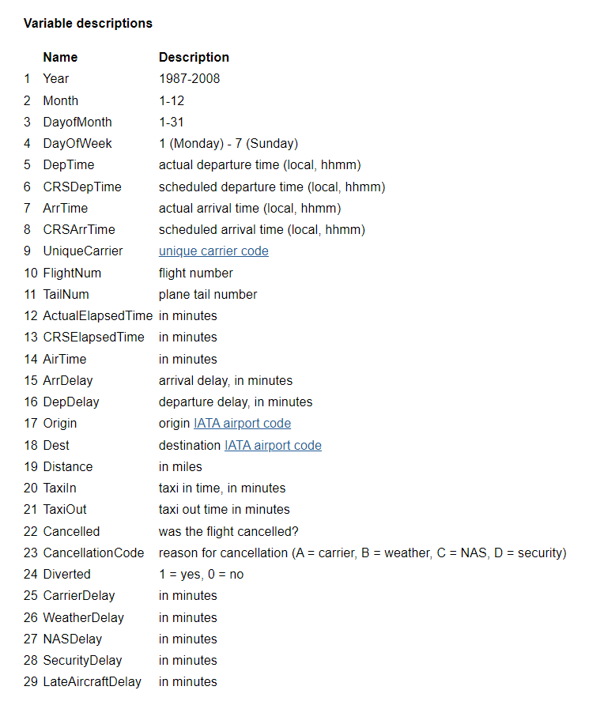

```python
# let's view summary statistics for the dataset
df.describe()
```

|  | Year | Month | DayofMonth | DayOfWeek | DepTime | CRSDepTime | ArrTime | CRSArrTime | FlightNum | ActualElapsedTime | CRSElapsedTime | AirTime | ArrDelay | DepDelay | Distance | TaxiIn | TaxiOut | Cancelled | Diverted | CarrierDelay | WeatherDelay | NASDelay | SecurityDelay | LateAircraftDelay |
| --- | --- | --- | --- | --- | --- | --- | --- | --- | --- | --- | --- | --- | --- | --- | --- | --- | --- | --- | --- | --- | --- | --- | --- | --- |
| count | 7009728.0 | 7.009728e+06 | 7.009728e+06 | 7.009728e+06 | 6.873482e+06 | 7.009728e+06 | 6.858079e+06 | 7.009728e+06 | 7.009728e+06 | 6.855029e+06 | 7.008884e+06 | 6.855029e+06 | 6.855029e+06 | 6.873482e+06 | 7.009728e+06 | 6.858079e+06 | 6.872670e+06 | 7.009728e+06 | 7.009728e+06 | 1.524735e+06 | 1.524735e+06 | 1.524735e+06 | 1.524735e+06 | 1.524735e+06 |
| mean | 2008.0 | 6.375130e+00 | 1.572801e+01 | 3.924182e+00 | 1.333830e+03 | 1.326086e+03 | 1.481258e+03 | 1.494801e+03 | 2.224200e+03 | 1.273224e+02 | 1.288668e+02 | 1.040186e+02 | 8.168452e+00 | 9.972570e+00 | 7.263870e+02 | 6.860852e+00 | 1.645305e+01 | 1.960618e-02 | 2.463006e-03 | 1.577206e+01 | 3.039031e+00 | 1.716462e+01 | 7.497434e-02 | 2.077098e+01 |
| std | 0.0 | 3.406737e+00 | 8.797068e+00 | 1.988259e+00 | 4.780689e+02 | 4.642509e+02 | 5.052251e+02 | 4.826728e+02 | 1.961716e+03 | 7.018731e+01 | 6.940974e+01 | 6.743980e+01 | 3.850194e+01 | 3.531127e+01 | 5.621018e+02 | 4.933649e+00 | 1.133280e+01 | 1.386426e-01 | 4.956753e-02 | 4.009912e+01 | 1.950287e+01 | 3.189495e+01 | 1.837940e+00 | 3.925964e+01 |
| min | 2008.0 | 1.000000e+00 | 1.000000e+00 | 1.000000e+00 | 1.000000e+00 | 0.000000e+00 | 1.000000e+00 | 0.000000e+00 | 1.000000e+00 | 1.200000e+01 | -1.410000e+02 | 0.000000e+00 | -5.190000e+02 | -5.340000e+02 | 1.100000e+01 | 0.000000e+00 | 0.000000e+00 | 0.000000e+00 | 0.000000e+00 | 0.000000e+00 | 0.000000e+00 | 0.000000e+00 | 0.000000e+00 | 0.000000e+00 |
| 25% | 2008.0 | 3.000000e+00 | 8.000000e+00 | 2.000000e+00 | 9.280000e+02 | 9.250000e+02 | 1.107000e+03 | 1.115000e+03 | 6.220000e+02 | 7.700000e+01 | 8.000000e+01 | 5.500000e+01 | -1.000000e+01 | -4.000000e+00 | 3.250000e+02 | 4.000000e+00 | 1.000000e+01 | 0.000000e+00 | 0.000000e+00 | 0.000000e+00 | 0.000000e+00 | 0.000000e+00 | 0.000000e+00 | 0.000000e+00 |
| 50% | 2008.0 | 6.000000e+00 | 1.600000e+01 | 4.000000e+00 | 1.325000e+03 | 1.320000e+03 | 1.512000e+03 | 1.517000e+03 | 1.571000e+03 | 1.100000e+02 | 1.100000e+02 | 8.600000e+01 | -2.000000e+00 | -1.000000e+00 | 5.810000e+02 | 6.000000e+00 | 1.400000e+01 | 0.000000e+00 | 0.000000e+00 | 0.000000e+00 | 0.000000e+00 | 6.000000e+00 | 0.000000e+00 | 0.000000e+00 |
| 75% | 2008.0 | 9.000000e+00 | 2.300000e+01 | 6.000000e+00 | 1.728000e+03 | 1.715000e+03 | 1.909000e+03 | 1.907000e+03 | 3.518000e+03 | 1.570000e+02 | 1.590000e+02 | 1.320000e+02 | 1.200000e+01 | 8.000000e+00 | 9.540000e+02 | 8.000000e+00 | 1.900000e+01 | 0.000000e+00 | 0.000000e+00 | 1.600000e+01 | 0.000000e+00 | 2.100000e+01 | 0.000000e+00 | 2.600000e+01 |
| max | 2008.0 | 1.200000e+01 | 3.100000e+01 | 7.000000e+00 | 2.400000e+03 | 2.359000e+03 | 2.400000e+03 | 2.400000e+03 | 9.743000e+03 | 1.379000e+03 | 1.435000e+03 | 1.350000e+03 | 2.461000e+03 | 2.467000e+03 | 4.962000e+03 | 3.080000e+02 | 4.290000e+02 | 1.000000e+00 | 1.000000e+00 | 2.436000e+03 | 1.352000e+03 | 1.357000e+03 | 3.920000e+02 | 1.316000e+03 |

```python
df.info() # viewing the info to chech the data types
```

```
<class 'pandas.core.frame.DataFrame'>
RangeIndex: 7009728 entries, 0 to 7009727
Data columns (total 29 columns):
Year                 int64
Month                int64
DayofMonth           int64
DayOfWeek            int64
DepTime              float64
CRSDepTime           int64
ArrTime              float64
CRSArrTime           int64
UniqueCarrier        object
FlightNum            int64
TailNum              object
ActualElapsedTime    float64
CRSElapsedTime       float64
AirTime              float64
ArrDelay             float64
DepDelay             float64
Origin               object
Dest                 object
Distance             int64
TaxiIn               float64
TaxiOut              float64
Cancelled            int64
CancellationCode     object
Diverted             int64
CarrierDelay         float64
WeatherDelay         float64
NASDelay             float64
SecurityDelay        float64
LateAircraftDelay    float64
dtypes: float64(14), int64(10), object(5)
memory usage: 1.5+ GB
```

all data types looks fine

```python
df.shape # viewing the shape of the data
```

```
(7009728, 29)
```

the data set is too large (7M observations) we might need to sample it to reduce the time of visualize

```python
print((df.isna().sum()/df.shape[0])* 100) # lets view the percintage of messing data in every column
```

```
Year                  0.000000
Month                 0.000000
DayofMonth            0.000000
DayOfWeek             0.000000
DepTime               1.943670
CRSDepTime            0.000000
ArrTime               2.163408
CRSArrTime            0.000000
UniqueCarrier         0.000000
FlightNum             0.000000
TailNum               1.189276
ActualElapsedTime     2.206919
CRSElapsedTime        0.012040
AirTime               2.206919
ArrDelay              2.206919
DepDelay              1.943670
Origin                0.000000
Dest                  0.000000
Distance              0.000000
TaxiIn                2.163408
TaxiOut               1.955254
Cancelled             0.000000
CancellationCode     98.039382
Diverted              0.000000
CarrierDelay         78.248300
WeatherDelay         78.248300
NASDelay             78.248300
SecurityDelay        78.248300
LateAircraftDelay    78.248300
dtype: float64
```

the data have alot of missing data but this is because alot of the flights isn't cancelled or delayed and there is multple features about cancilation and delay

```python
df_cancelled = df[df["Cancelled"] == 1] # let's creat a dataframe for cancelled flights
```

```python
df["CancellationCode"].value_counts() # let's view the reason for cancellation
```

```
B    54904
A    54330
C    28188
D       12
Name: CancellationCode, dtype: int64
```

```python
# let's create a function for bar plots to easly creat bar plots without repeating codes
def bar_plot (column, X_label, Y_label, title) :
    """
    input :
        column : dataframe column (df["column name"])
        x_label : plot name of the x axes
        y_label : plot name of the y axis
        title   : plot title
    output bar plot
    """
    x = column.value_counts().index
    y = column.value_counts().values
    plt.figure(figsize=(10,6))
    plt.bar(x, y)
    plt.xticks(x);
    plt.xlabel(X_label)
    plt.ylabel(Y_label)
    plt.title(title)
```

## Univariate Exploration

we will start with univariate exploration of the data

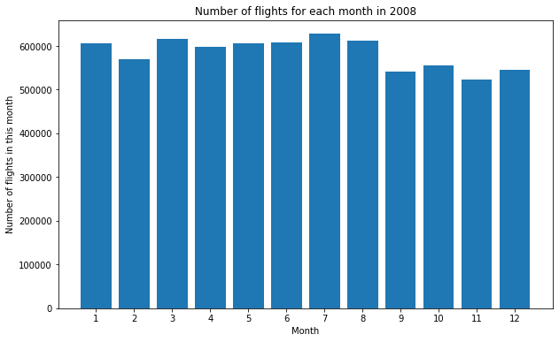

```python
# exploring number of flights in every month
bar_plot(df["Month"], "Month","Number of flights in this month", "Number of flights for each month in 2008")
```

july have the highest number of flights in

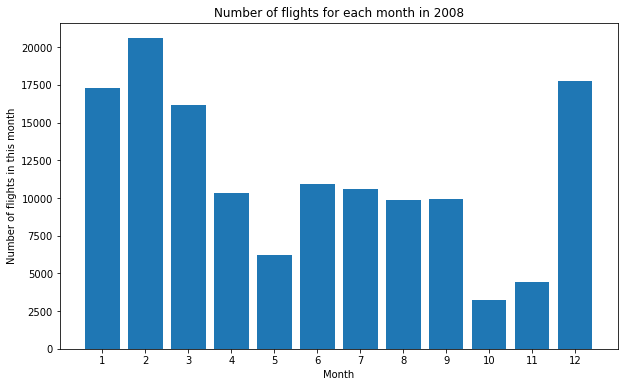

```python
# exploring number of flights cancelled in every month
bar_plot(df_cancelled["Month"], "Month","Number of flights in this month", "Number of flights for each month in 2008")
```

October have the lowest number of canceled flights but February have the highest number of canceled flights

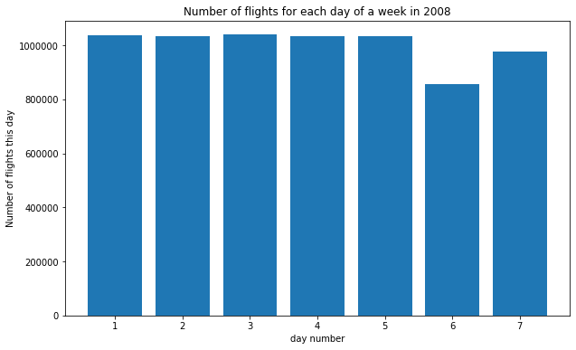

```python
# exploring number of flights every day of the week
bar_plot(df['DayOfWeek'], "day number", "Number of flights this day", "Number of flights for each day of a week in 2008")
```

saturday has the least number of flights

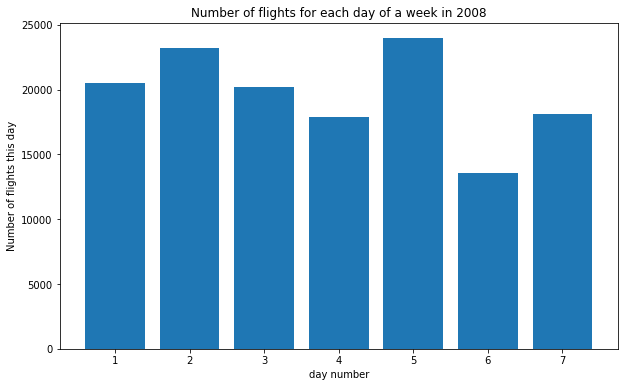

```python
# exploring number of cancelled flights every day of the week
bar_plot(df_cancelled['DayOfWeek'], "day number", "Number of flights this day", "Number of flights for each day of a week in 2008")
```

saturday has the least number of cancelled flights

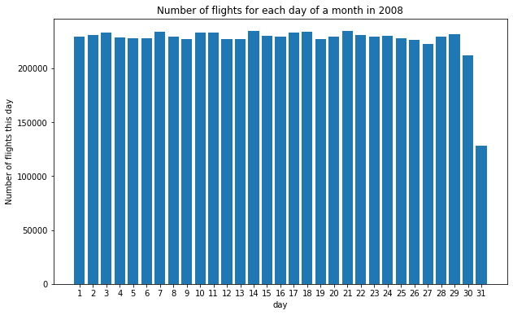

```python
# exploring number of flights every day of the month
bar_plot(df['DayofMonth'], "day", "Number of flights this day", "Number of flights for each day of a month in 2008")
```

day 31 have the least number of flights in the year which is predictable as not all months contain 31 days

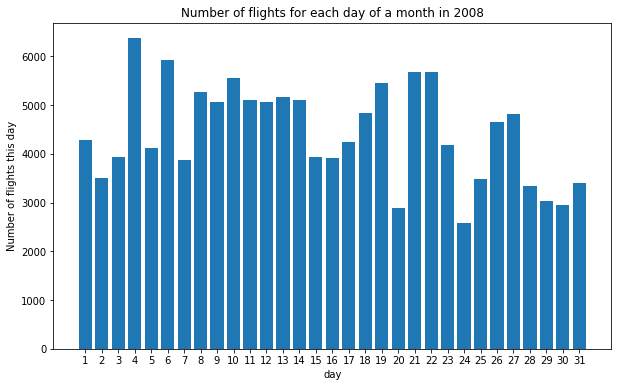

```python
# exploring number of cancelled flights every day of the month
bar_plot(df_cancelled['DayofMonth'], "day", "Number of flights this day", "Number of flights for each day of a month in 2008")
```

day 4 has the hieghest number of cancelled flights

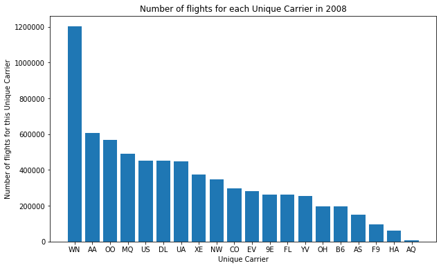

```python
bar_plot(df['UniqueCarrier'], "Unique Carrier", "Number of flights for this Unique Carrier", "Number of flights for each Unique Carrier in 2008")
```

WN carrier has the highest number of flights

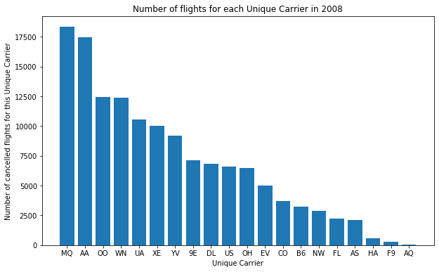

```python
bar_plot(df_cancelled['UniqueCarrier'], "Unique Carrier", "Number of cancelled flights for this Unique Carrier", "Number of flights for each Unique Carrier in 2008")
```

MQ carrier has the highest number of cancelled flights

```python
# selicting continues features to
cont_columns=['DepTime', 'CRSDepTime', 'ArrTime', 'CRSArrTime', 'ActualElapsedTime', 'CRSElapsedTime', 'AirTime', 'ArrDelay', 'DepDelay', 'Distance']
```

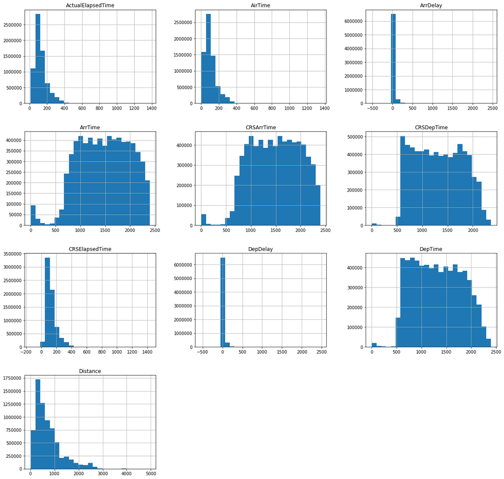

```python
# let's view the histogram for each continuous feature
df.hist(column = cont_columns, figsize = (20,20), bins = 25);
```

most of the continuous features are skewed to the rights and there is no gaussian distribution

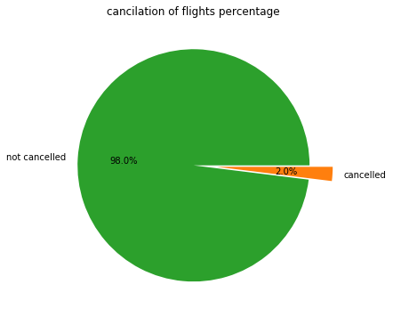

```python
# let's view the percintage of cancelled flights
explode = [0,0.2]
plt.figure(figsize = (10,6))
values = df["Cancelled"].value_counts().values
label = ["not cancelled", "cancelled"]
plt.pie(values, explode=explode, labels = label, colors = ["tab:green", "tab:orange"], autopct='%0.1f%%');
plt.title("cancilation of flights percentage");
```

2% of flights are cancelled

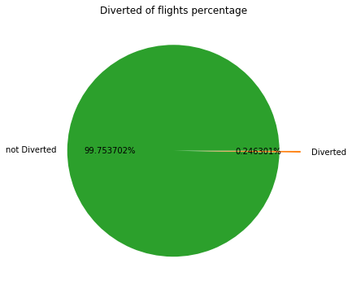

```python
# let's view the percintage of Diverted flights
explode = [0,0.2]
plt.figure(figsize = (10,6))
values = df["Diverted"].value_counts().values
label = ["not Diverted", "Diverted"]
plt.pie(values, explode=explode, labels = label, colors = ["tab:green", "tab:orange"],autopct='%01f%%');
plt.title("Diverted of flights percentage");
```

0.25% of flights are diverted

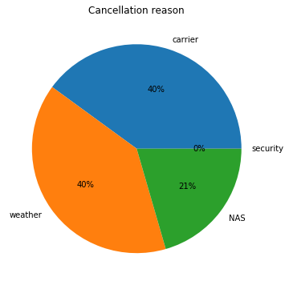

```python
# exploring cancilation reasons
plt.figure(figsize = (10,6))
values = df["CancellationCode"].value_counts().values
label =  ["carrier", "weather", "NAS", "security"]
plt.pie(values, labels = label,autopct='%1.0f%%');
plt.title("Cancellation reason");
```

most of flights (80%) are cancelled beacuse of weather of carrier reasons

## Bivariate Exploration

```python
# using a sample of 100k to reduce the time to plot the relation ship as the data set is to large and takes alot of time to visualize (7M)
df_sample = df.sample(100000)
```

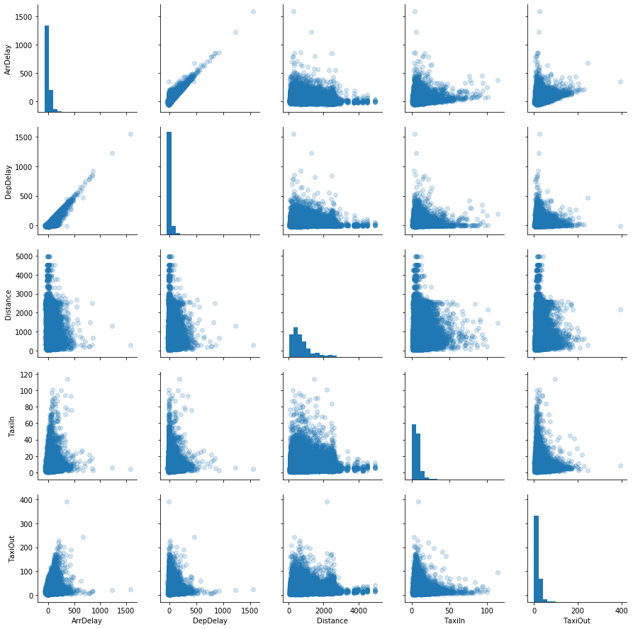

```python
# let's select some features to see the relation sips betwean each other

selected_columns = ['ArrDelay','DepDelay', 'Distance', 'TaxiIn', 'TaxiOut']

# plot
Pair_grid = sb.PairGrid(data=df_sample, vars= selected_columns)
Pair_grid.map_diag(plt.hist, bins=20); # plot hist with 20 bin
Pair_grid.map_offdiag(plt.scatter, alpha=0.2); # scatter plot with alpha 0.2
```

there are some strong positive correlation between arrival delay and departure delay we will explore later

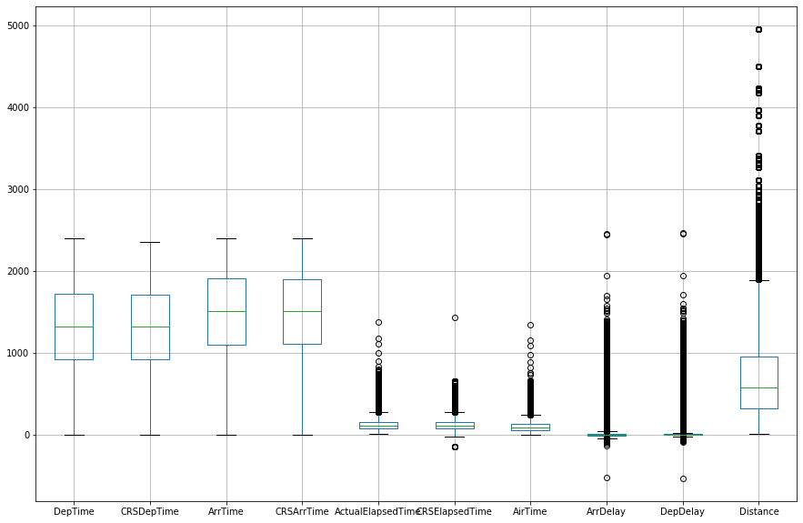

```python
# let's view the box plot for continuous features
plt.figure(figsize = (15,10))
df.boxplot(cont_columns);
```

some features has alot of outliers

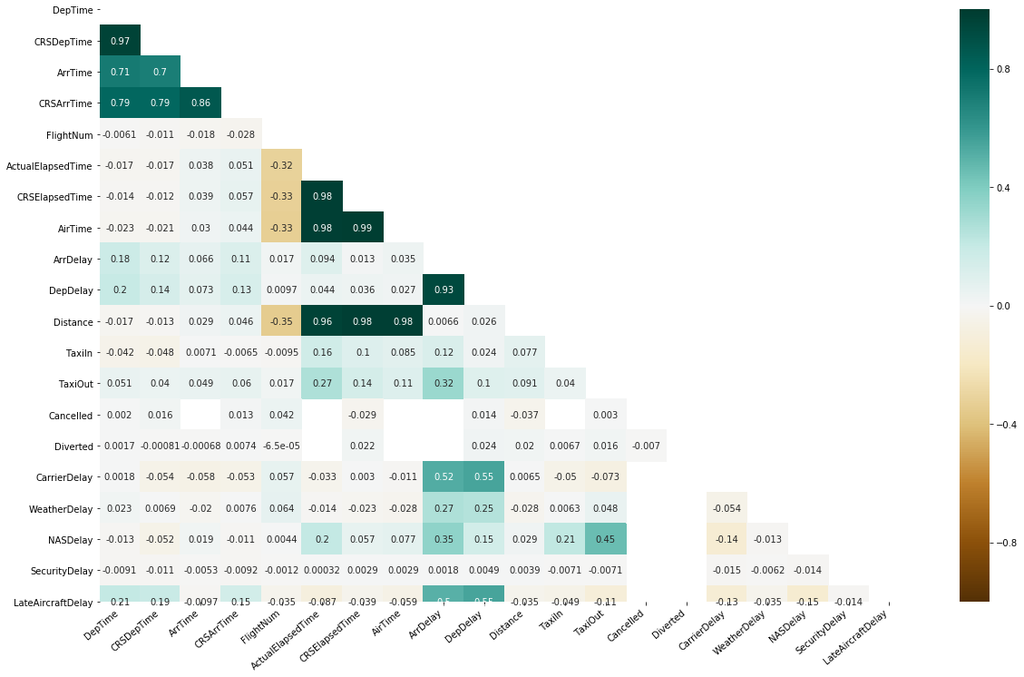

```python
# let's view the corrilation heatmap for each feature
df_without_date = df.loc[:,"DepTime":"LateAircraftDelay"] # slicceng the data  frame as the correlation betwean year, month , day isn't important
plt.figure(figsize=(20,12))
mask = np.triu(np.ones_like(df_without_date.corr(), dtype=np.bool))

heatmap = sb.heatmap(df_without_date.corr(), mask = mask,annot=True, cmap='BrBG',vmin=-1, vmax=1);
# heatmap.set_title('Correlation Heatmap', fontdict={'fontsize':12}, pad=12);
heatmap.set_xticklabels(heatmap.get_xticklabels(), rotation=40, ha="right");
```

```python
# let's create a function for easear scatter plots
def scatter_plot(x_column_name, y_column_name, x_label, y_label, title):
    """
    input :
        x_column_name : dataframe column (df["column name"]) for the x axis
        y_column_name : dataframe column (df["column name"]) for the y axis
        x_label : plot name of the x axes
        y_label : plot name of the y axis
        title   : plot title
    output bar plot
    """
    plt.figure(figsize=(16,9))
    sb.regplot(data = df_sample, x= x_column_name,y= y_column_name, scatter_kws={'alpha':0.3});
    plt.xlabel(x_label)
    plt.ylabel(y_label)
    plt.title(title)
```

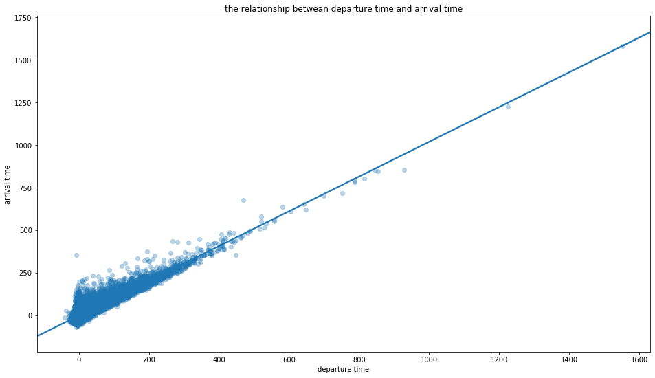

```python
# exploring the relationship betwean departure time and arrival time
scatter_plot("DepDelay", 'ArrDelay', "departure time", "arrival time", "the relationship betwean departure time and arrival time")
```

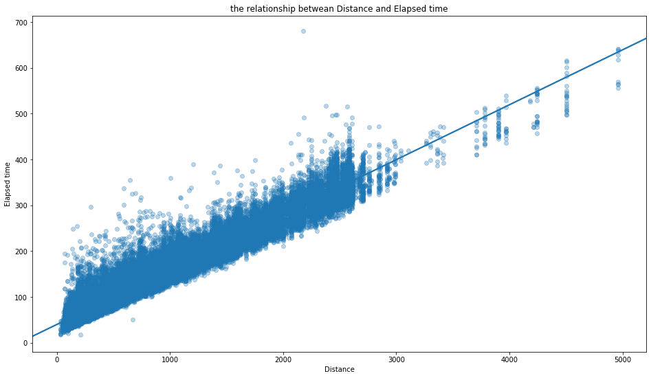

```python
# exploring the relationship betwean Distance and Elapsed time
scatter_plot("Distance", 'ActualElapsedTime', "Distance", "Elapsed time", "the relationship betwean Distance and Elapsed time")
```

from the plot Distance and Elapsed time are strongly correleted

## Multivariate Exploration

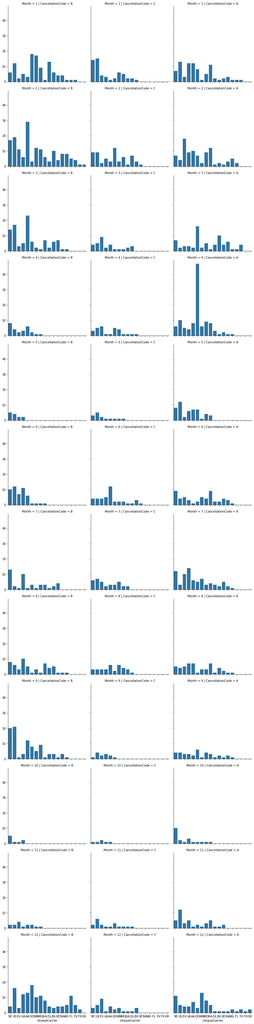

```python
# let's view the relation betwean the cancellation code and carrier id and month
FacetGrid = sb.FacetGrid(df_sample, col = "CancellationCode",row = 'Month' , height=4)
FacetGrid.map(sb.countplot, "UniqueCarrier")
plt.show()
```

months like april and may cancillation reasons is too low for B (weather) as the weater is these monthes is the best , also the cancellation reason for months like december and january and february increases for weather as the weather in these months isn't the best for flights

## Modeling

can we predict if a fligh be cancelled or not ?? we will use some machine learning models to predict so

```python
# importing sklearn important functions to split the data set and test our model
from sklearn.model_selection import train_test_split
from sklearn.metrics import classification_report,accuracy_score
```

```python
# splitting the data set into two, one contains independent variables and the other contains the dependant variable
Y = df['Cancelled']
X = df.drop(['Cancelled', ],axis=1)
# dropig some feature that can affect our model
X = X.drop(['TailNum', ],axis=1)
X = X.drop(['CancellationCode', ],axis=1)
```

```python
# encoding catigorical variables into numerical ones
from sklearn import preprocessing
le = preprocessing.LabelEncoder()
X.UniqueCarrier = le.fit_transform(X.UniqueCarrier)
X.Dest = le.fit_transform(X.Dest)
X.Origin = le.fit_transform(X.Origin)
```

```python
# filling nan variables with -1
X.fillna(-1, inplace = True)
```

```python
# let's check our independent variable dataframe
X.head()
```

|  | Year | Month | DayofMonth | DayOfWeek | DepTime | CRSDepTime | ArrTime | CRSArrTime | UniqueCarrier | FlightNum | ActualElapsedTime | CRSElapsedTime | AirTime | ArrDelay | DepDelay | Origin | Dest | Distance | TaxiIn | TaxiOut | Diverted | CarrierDelay | WeatherDelay | NASDelay | SecurityDelay | LateAircraftDelay |
| --- | --- | --- | --- | --- | --- | --- | --- | --- | --- | --- | --- | --- | --- | --- | --- | --- | --- | --- | --- | --- | --- | --- | --- | --- | --- | --- |
| 0 | 2008 | 1 | 3 | 4 | 2003.0 | 1955 | 2211.0 | 2225 | 17 | 335 | 128.0 | 150.0 | 116.0 | -14.0 | 8.0 | 135 | 286 | 810 | 4.0 | 8.0 | 0 | -1.0 | -1.0 | -1.0 | -1.0 | -1.0 |
| 1 | 2008 | 1 | 3 | 4 | 754.0 | 735 | 1002.0 | 1000 | 17 | 3231 | 128.0 | 145.0 | 113.0 | 2.0 | 19.0 | 135 | 286 | 810 | 5.0 | 10.0 | 0 | -1.0 | -1.0 | -1.0 | -1.0 | -1.0 |
| 2 | 2008 | 1 | 3 | 4 | 628.0 | 620 | 804.0 | 750 | 17 | 448 | 96.0 | 90.0 | 76.0 | 14.0 | 8.0 | 140 | 48 | 515 | 3.0 | 17.0 | 0 | -1.0 | -1.0 | -1.0 | -1.0 | -1.0 |
| 3 | 2008 | 1 | 3 | 4 | 926.0 | 930 | 1054.0 | 1100 | 17 | 1746 | 88.0 | 90.0 | 78.0 | -6.0 | -4.0 | 140 | 48 | 515 | 3.0 | 7.0 | 0 | -1.0 | -1.0 | -1.0 | -1.0 | -1.0 |
| 4 | 2008 | 1 | 3 | 4 | 1829.0 | 1755 | 1959.0 | 1925 | 17 | 3920 | 90.0 | 90.0 | 77.0 | 34.0 | 34.0 | 140 | 48 | 515 | 3.0 | 10.0 | 0 | 2.0 | 0.0 | 0.0 | 0.0 | 32.0 |

```python
x_train, x_test, y_train, y_test = train_test_split(X,Y,test_size=0.3,train_size=0.7)
```

```python
# I will use logistic regression for classification
from sklearn.linear_model import LogisticRegression
log=LogisticRegression(random_state=110)
log.fit(x_train,y_train)
```

```
LogisticRegression(C=1.0, class_weight=None, dual=False, fit_intercept=True,
                   intercept_scaling=1, l1_ratio=None, max_iter=100,
                   multi_class='warn', n_jobs=None, penalty='l2',
                   random_state=110, solver='warn', tol=0.0001, verbose=0,
                   warm_start=False)
```

```python
# let's test our model
prediction =  log.predict(x_test)
print(accuracy_score(prediction,y_test))
```

```
0.9999191599866661
```

```python
print(classification_report(prediction,y_test))
```

```
              precision    recall  f1-score   support

           0       1.00      1.00      1.00   2061753
           1       1.00      1.00      1.00     41166

    accuracy                           1.00   2102919
   macro avg       1.00      1.00      1.00   2102919
weighted avg       1.00      1.00      1.00   2102919
```

our model accuracy is too high but this can be due to the number of features we have which make it easer for the model to correctly predict if a flight will be cancelled or not

## Limitations

- some features has alot of missing values (98%, 78%) which make it very hard to drop or to fill with other value or trying to predict a value for the missing data